# Machine Learning

# Machine Learning

- We’ll give an overview of some basic machine learning tools.
- The goal here is to give you some options to consider when you are completing your final projects.
- You are not required to use any particular tool. If a ML model makes sense for your analysis, then its a good way to do something cool, but you can do a good project that relies on simpler approaches.

# Machine Learning

We’ll primarily use [scikit-learn](https://scikit-learn.org/stable/index.html) for machine learning, but this integrates well with libraries like Pandas.

# Machine Learning

- “Machine learning” is kind of a buzzword. But it refers to a broad set of methods for extracting meaning and structure from data to make predictions or analyze relationships.
- We can class models into two big categories: supervised models and unsupervised models.

# Supervised models

- Supervised models predict Y (labels) using X (one or more features)
- Find some function $f(x)$ that minimizes the error in predicting y.

| Obs. | X1 | X2 | X3 | Y |
| --- | --- | --- | --- | --- |
| 1 | 39.1 | 18.7 | 181 | 1 |
| 2 | 39.5 | 17.4 | 186 | 0 |
| 3 | 40.3 | 18 | 195 | 0 |
| 4 | 36.7 | 19.3 | 193 | 0 |
| 5 | 39.3 | 20.6 | 190 | 1 |

# Unsupervised models

- Unsupervised models attempt to identify patterns in unlabeled data. For example:
  - Finding “clusters” of similar observations
  - Creating simplified representations of complex data sets.

| Obs. | X1 | X2 | X3 |
| --- | --- | --- | --- |
| 1 | 39.1 | 18.7 | 181 |
| 2 | 39.5 | 17.4 | 186 |
| 3 | 40.3 | 18 | 195 |
| 4 | 36.7 | 19.3 | 193 |
| 5 | 39.3 | 20.6 | 190 |

# Basic steps

1. Select features
2. Create training and testing sets
3. If needed, pre-process the data.
4. Fit the model to the training data.
5. Evaluate the model on the testing data.

# Predicting county-level election results

- For instance, I have data on county-level election results from the 2024 and 2020 elections.
- My outcome here is the percent of the vote in that county that went to Democrats.
- My features include demographic data from the U.S. census.

(In practice, good election prediction models would include a lot more data - including information about things like the national economy, approval ratings, and data from multiple cycles)

## Election Data

```
     state           county  year  mean_income  percent_employed   per_dem
0  Alabama   Autauga County  2024       109137              59.0  0.263888
1  Alabama   Baldwin County  2024       119421              58.3  0.204699
2  Alabama   Barbour County  2024        77821              44.9  0.422905
3  Alabama      Bibb County  2024        79298              51.6  0.175197
4  Alabama    Blount County  2024        91220              57.4  0.091624
5  Alabama   Bullock County  2024        66381              46.6  0.726498
6  Alabama    Butler County  2024        85293              53.1  0.383961
7  Alabama   Calhoun County  2024        87795              55.8  0.271873
8  Alabama  Chambers County  2024        76301              55.2  0.380072
9  Alabama  Cherokee County  2024        84396              50.8  0.119609
```

## Regression

- Since my outcome is (more or less) continuous, I can use methods like linear regression to draw a “line of best fit” through the data.

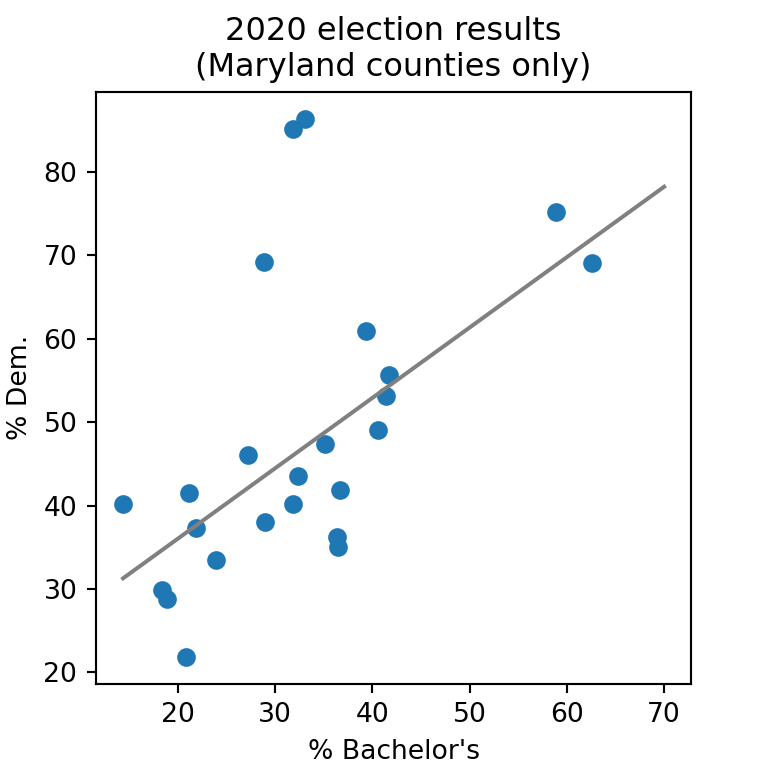

## Regression

- Since my outcome is (more or less) continuous, I can use methods like linear regression to draw a “line of best fit” through the data.
- In OLS, the “best” line is the one minimizes the squared differences between predictions vs. observed values.

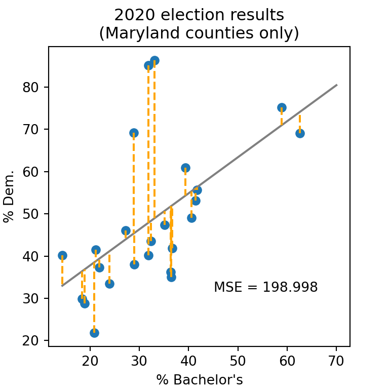

## Regression: cheating

However!

- It’s easy to get carried away here, essentially modeling the noise in our sample. (in this case, I used up to 9th degree polynomials of % bachelors)
- Models like this will have a low MSE for our sample, but make bad predictions out of the sample.

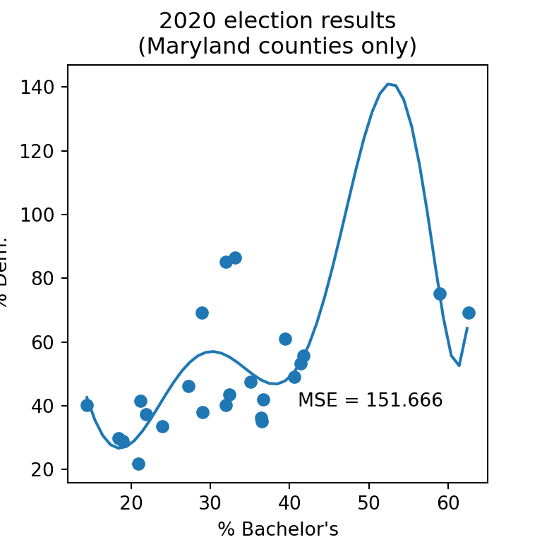

## Regression: cheating

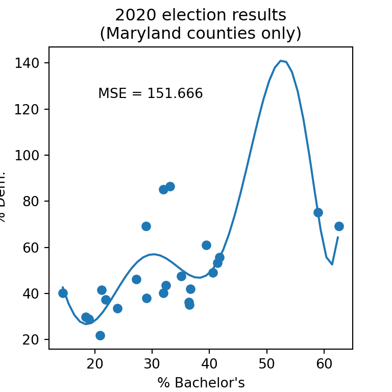

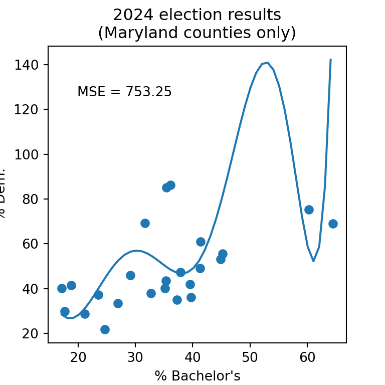

The actual outcomes here aren’t all that different, but the model performs poorly even on very similar data because it’s essentially “memorized” the 2020 results.

## Regression: cheating

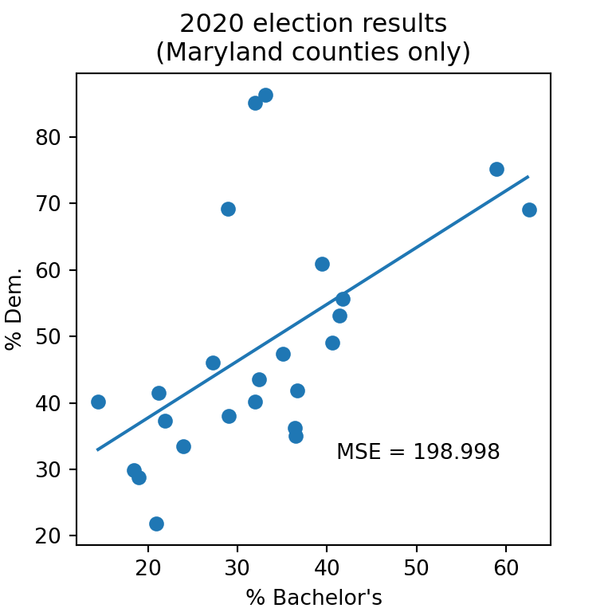

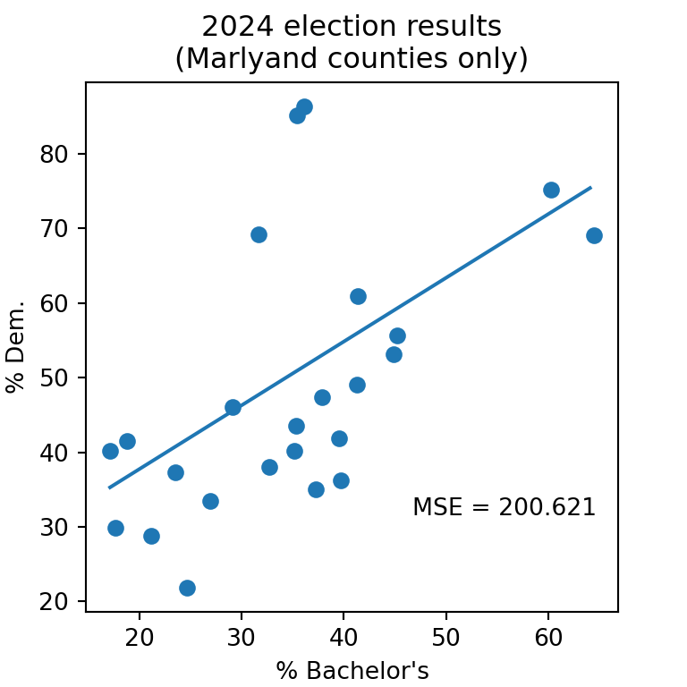

## Train-test splits

- This is why splitting up “training” and “testing” data is essential: we want to give a realistic picture of how the model will perform on new data.
- Since we have data from two separate years here, a natural approach would be to use 2020 to fit a model and 2024 results to assess the predictions, but in other cases we’ll use random subsets for training/testing.

## 1. Select features

- For this example, I’ll use the number of households, mean income, and % bachelor’s degrees as my predictors. I’ll call those variables “X”
- My outcome is “percent Democratic vote share”. I’ll call that variable “y”

```python
import pandas as pd
import numpy as np

election_data = pd.read_csv("election_data.csv")

features = ['num_households','mean_income', 'percent_bachelors']
outcome = ['per_dem']



# select predictors/outcome
X = election_data[features]
y = election_data[outcome]
```

## 2. Create training and testing sets

- I’ll use 2020 data for training, and 2024 data for testing.

```python
train_index = election_data['year']==2020
test_index = election_data['year'] == 2024

# Split data
X_train = X.loc[train_index]
y_train = y.loc[train_index]

# data for testing
X_test = X.loc[test_index]
y_test = y.loc[test_index]
```

## 3. Pre-process the data

Since some of the predictors have very different scales, and these scaling differences can impact model performance.

Scaling the variables (mean-centering and division by the standard error) will ensure that all of our predictors have the same mean and standard deviation.

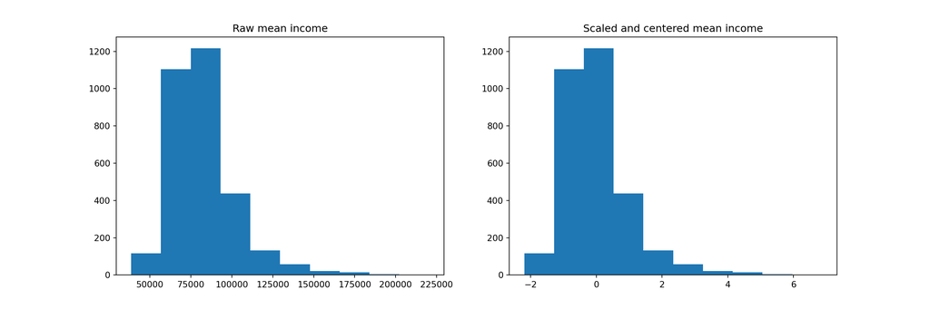

## 3. Pre-process the data

Always use the same pre-processing steps on the training and testing data.

- Use `.fit_transform` to apply scaling on the training data.
- Use `.transform` to apply a pre-existing transformation to test data.

```python
from sklearn.preprocessing import StandardScaler


# Scaling predictors
scaler = StandardScaler()
X_train_scaled = scaler.fit_transform(X_train)
X_test_scaled = scaler.transform(X_test)
```

## 4. Fit to the training data

Now we fit the model by calling `LinearRegression().fit(X, y)`

```python
from sklearn.linear_model import LinearRegression

# Fit model on training data
model = LinearRegression().fit(X_train_scaled, y_train)

# Inspecting the coefficients
[(i, f'{j:.3f}') for i, j in zip(features,model.coef_.tolist()[0])]
```

```
[('num_households', '0.032'), ('mean_income', '-0.038'), ('percent_bachelors', '0.107')]
```

## 5. Evaluate on the testing data

- We’ll use `.predict()` to make new predictions from a fitted model.
- We can use [metrics](https://scikit-learn.org/stable/modules/model_evaluation.html) to see how well the model performs on the testing data.

```python
from sklearn.metrics import mean_squared_error
from sklearn.metrics import r2_score

# getting predictions for 2024:
y_pred = model.predict(X_test_scaled)



print("MSE:", mean_squared_error(y_test, y_pred),
      "\nR^2:" , r2_score(y_test, y_pred)
)
```

```
MSE: 0.015942709294787957
R^2: 0.3407111812314362
```

## 5. Evaluate on the testing data

```python
pred_df = pd.DataFrame(y_pred)

pred_df = pd.concat([pred_df, y_test], axis=1)
pred_df.columns = ['prediction', 'outcome']
pred_df.plot.scatter(x='prediction', y='outcome', alpha=.7)
plt.axline((0, 0), slope=1, color='black', linestyle='--', label='')
plt.xlim(0, 1.1)
```

```
(0.0, 1.1)
```

```python
plt.ylim(0, 1.1)
```

```
(0.0, 1.1)
```

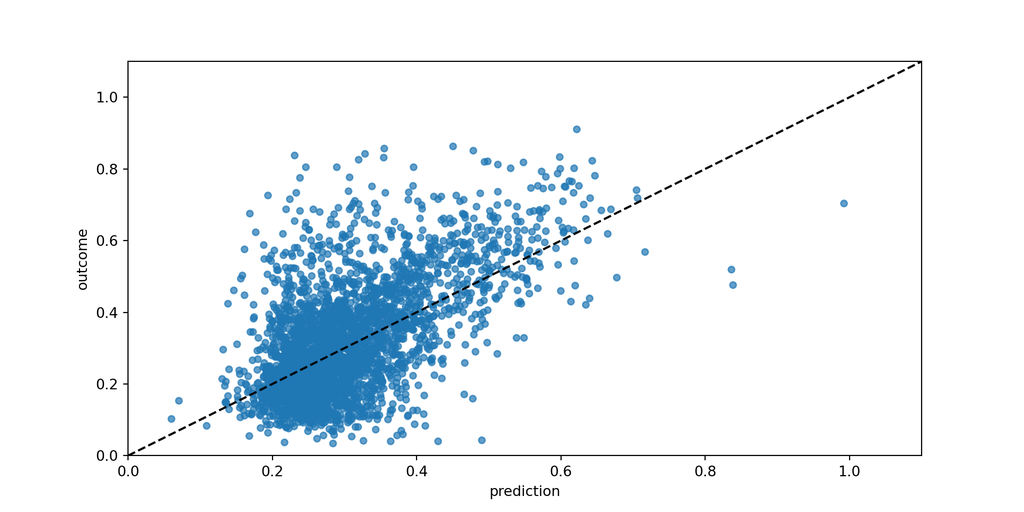

```python
plt.show()
```

## Try it out

The `election_data.csv` file has some additional predictors that you might try to use. See if you can improve the results by either: including additional predictors, applying [different transformations](https://scikit-learn.org/stable/modules/preprocessing.html#), or using a different regression estimator.

Here’s the whole script together for reference:

```python
import pandas as pd
import numpy as np
from sklearn.preprocessing import StandardScaler
from sklearn.linear_model import LinearRegression
from sklearn.metrics import mean_squared_error
from sklearn.metrics import r2_score

election_data = pd.read_csv("election_data.csv")

# 1. select predictors/outcome ----

features = ['num_households','mean_income', 'percent_bachelors']
outcome = ['per_dem']
X = election_data[features]
y = election_data[outcome]

# 2. Split data ------

train_index = election_data['year'] == 2020
test_index  = election_data['year'] == 2024
# training data
X_train = X.loc[train_index]
y_train = y.loc[train_index]

# testing data
X_test = X.loc[test_index]
y_test = y.loc[test_index]

## 3. Pre-process -----

scaler = StandardScaler()
X_train_scaled = scaler.fit_transform(X_train)
X_test_scaled = scaler.transform(X_test)

# 4. Fit model on training data ----

model = LinearRegression().fit(X_train_scaled, y_train)

# 5. Assess model fit ----

y_pred = model.predict(X_test_scaled)


# getting predictions for 2024:
y_pred = model.predict(X_test_scaled)



print("MSE:", mean_squared_error(y_test, y_pred),
      "\nR^2:" , r2_score(y_test, y_pred)
)
import plotly.express as px
pred_df = pd.DataFrame(y_pred)
pred_df = pd.concat([pred_df, y_test], axis=1)
pred_df.columns = ['prediction', 'outcome']

fig = px.scatter(pred_df, x='prediction', y='outcome')
fig.show()
```

# Supervised Learning for Categories

- What if my “labels” are something like a “yes” or “no” outcome? Regression models “draw a line” through data, but we can’t really “draw a line” through a categorical outcome.

## Supervised Learning for Categories

GTD data

| variable | description |
| --- | --- |
| country | Country name |
| country_text_id | 3-letter country code |
| gdp_pcap | GDP per capita (World Bank) |
| population | Population (World Bank) |
| unemployment_rate | Unemployment rate (World Bank) |
| gdp_growth | GDP growth % (World Bank) |
| resource_rents | Natural resource rents (% of GDP) |
| oil | Oil rents (% of GDP) |
| life_expectancy | Life Expectancy at birth (World Bank) |
| liberal_democracy | Liberal democracy score (V-DEM) |
| autonomy | Level of political autonomy (V-DEM) |
| political_stability | Political Stability (World Bank Governance Indicators) |
| any_attacks_prior_year | Any attacks in 2019 (GTD) |
| any_attacks | Any attacks in 2020 (GTD) |

## Supervised Learning for Categories

I’m interested in predicting terrorist attacks in 2020 using this data set. But the `any_attacks` variable is coded as “Yes” or “No”.

```python
gtd = pd.read_csv("gtd_data.csv")

gtd.head()[['country', 'any_attacks']]
```

```
       country any_attacks
0  Afghanistan         yes
1      Albania         yes
2      Algeria         yes
3       Angola          no
4    Argentina         yes
```

## Supervised Learning for Categories

I can “dummify” categorical variables to make them into a 1 or 0 variable. This creates k-1 dummies for each level of the categorical variable, with each taking on a zero or one value:

```python
gtd_dummified = pd.get_dummies(gtd, columns=['any_attacks','any_attacks_prior_year', 'autonomy'],
                            drop_first=True, dtype='int')

gtd_dummified.head()[['country','any_attacks_yes']]
```

```
       country  any_attacks_yes
0  Afghanistan                1
1      Albania                1
2      Algeria                1
3       Angola                0
4    Argentina                1
```

## Supervised Learning for Categories

But it still doesn’t really make sense to think of drawing a straight line through this.

```python
gtd_dummified.plot.scatter(y = 'any_attacks_yes', x = 'gdp_pcap');
```

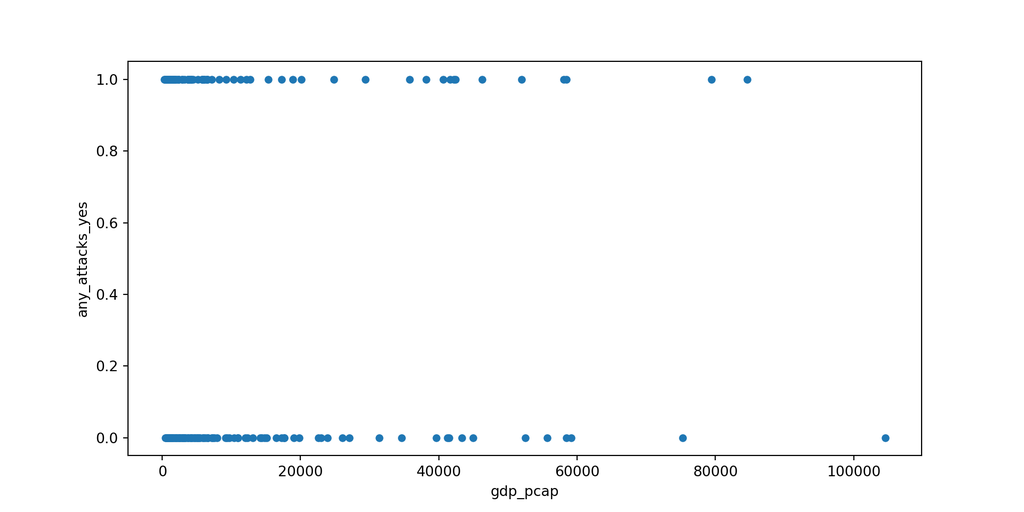

## Supervised Learning for Categories

Fortunately, we have lots of models that can work with categorical data.

- Logistic regression (the closest to a regular regression model) uses a sigmoid function to model the probability the outcome being “TRUE” or 1.
- Others include: Naive Bayes, Support Vector Machines, Tree-based classifiers, and neural networks.

## Logistic Regression: Setup

We’ll train a logistic regression model. We don’t have data from two different years here, so we’re going to create a “train” and “test” set by randomly leaving out 30% of the observations.

The `train_test_split` function from scikit-learn can do this for us automatically:

```python
from sklearn.model_selection import train_test_split
gtd_features = gtd_dummified[['gdp_pcap', 'oil', 'liberal_democracy','political_stability']]
gtd_outcome = gtd_dummified['any_attacks_yes']

train_X, test_X, train_y, test_y = train_test_split(gtd_features,
                                                    gtd_outcome,
                                                    test_size=0.30,
                                                    random_state=20)
```

## Logistic Regression: Setup

We’ll also standardize the predictors in both groups. This isn’t always necessary but some models will fail to converge when the predictors have very different scalings, so standardization is a good way to address this.

```python
scaler = StandardScaler()
X_train_scaled = scaler.fit_transform(train_X)
X_test_scaled = scaler.transform(test_X)
```

# Logistic Regression

We’ll fit a logistic regression model using the training data. And then predict using the test data that was randomly held out. How many of the predictions from the model are correct?

```python
from sklearn.linear_model import LogisticRegression
logitmodel = LogisticRegression(random_state=0).fit(X_train_scaled, train_y)
# predict using the testing data:
predictions = logitmodel.predict(X_test_scaled)
pd.crosstab(predictions, test_y, rownames=['Prediction'], colnames=['Actual Outcome'])
```

```
Actual Outcome   0   1
Prediction
0               16   3
1               11  21
```

## Assessing predictions

- When classifying data into groups, “accuracy” may not be the best metric. If a category is very rare, we can “predict” it easily by just always guessing 0
- Confusion matrices are a useful way to just the quality of a categorical classifier.

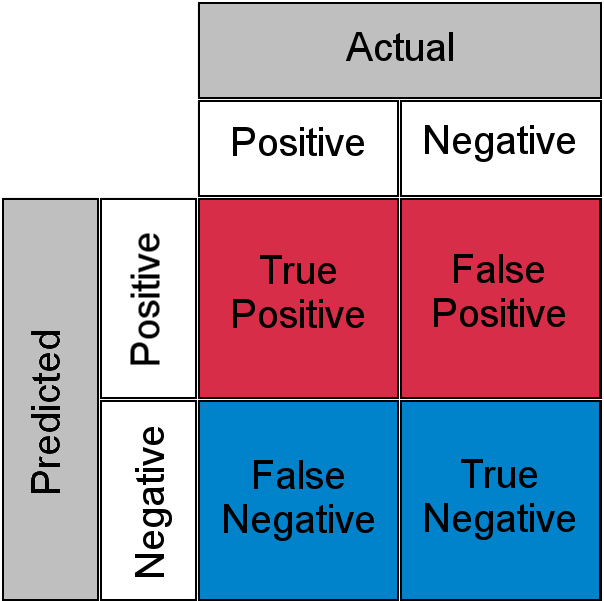

## Assessing predictions

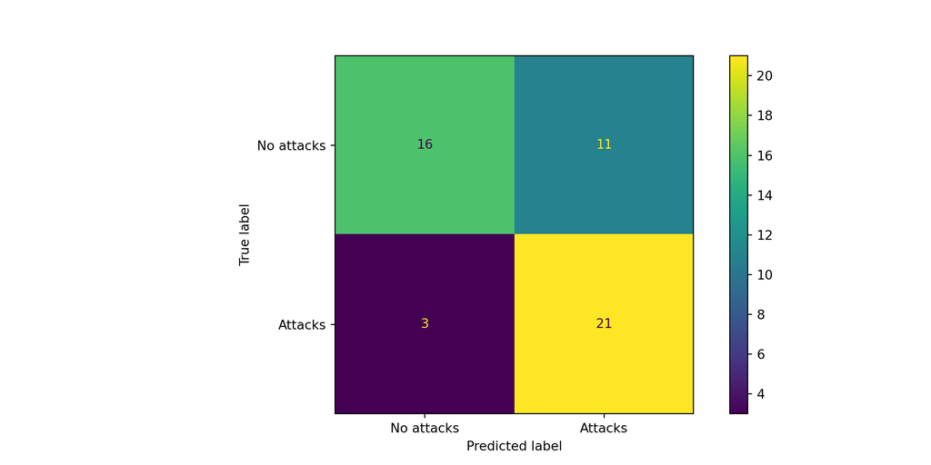

```python
from sklearn.metrics import confusion_matrix
from sklearn.metrics import ConfusionMatrixDisplay


cm = confusion_matrix(test_y, predictions)
mat = ConfusionMatrixDisplay(confusion_matrix = cm, display_labels= ['No attacks', "Attacks"] ).plot()
plt.show()
```

## Assessing predictions

- **Precision:** the % of predicted positive cases that were actually positive
- **Recall:** the % of actually positive cases that were predicted positive
- **Accuracy:** the % of predicted cases that are accurate
- **Cohen’s Kappa:** a measure of how much predictions are improved compared to a random guess
- **Balanced Accuracy:** a measure of accuracy that’s adjusted for imbalanced data
- **F-1:** a kind of balanced average of precision and recall (harmonic mean)

I’m personally partial to Cohen’s Kappa and balanced accuracy, because they’re easy to compare across models.

## Assessing predictions

Here are some of those stats for this model:

```python
from sklearn.metrics import accuracy_score, cohen_kappa_score, f1_score, classification_report, balanced_accuracy_score

print(classification_report(test_y, predictions,
                            # add target_names to show labels in the report:
                            target_names=['No attacks', 'Attacks']))
```

```
              precision    recall  f1-score   support

  No attacks       0.84      0.59      0.70        27
     Attacks       0.66      0.88      0.75        24

    accuracy                           0.73        51
   macro avg       0.75      0.73      0.72        51
weighted avg       0.75      0.73      0.72        51
```

```python
print("cohens kappa: ", cohen_kappa_score(test_y,  predictions))
```

```
cohens kappa:  0.4590909090909091
```

```python
print("balanced accuracy: ", balanced_accuracy_score(test_y, predictions))
```

```
balanced accuracy:  0.7337962962962963
```

## Try it out

See if you can improve on this result by adding additional features or try a different classifier.

```python
from sklearn.linear_model import LogisticRegression
from sklearn.model_selection import train_test_split
from sklearn.preprocessing import StandardScaler
from sklearn.metrics import accuracy_score, cohen_kappa_score, f1_score, classification_report, balanced_accuracy_score

import matplotlib.pyplot as plt
import pandas as pd

# read data
gtd = pd.read_csv("gtd_data.csv")
gtd_dummified = pd.get_dummies(gtd, columns=['any_attacks','any_attacks_prior_year', 'autonomy'],
                            drop_first=True, dtype='int')
gtd_features = gtd_dummified[['gdp_pcap', 'oil', 'liberal_democracy','political_stability']]
gtd_outcome = gtd_dummified['any_attacks_yes']

# split train/test data
X_train, X_test, y_train, y_test = train_test_split(gtd_features,
                                                    gtd_outcome,
                                                    test_size=0.30,
                                                    random_state=20)
# Standardize features
scaler = StandardScaler()
X_train_scaled = scaler.fit_transform(X_train)
X_test_scaled = scaler.transform(X_test)

# Apply logistic regression
logitmodel = LogisticRegression(random_state=0).fit(X_train_scaled, y_train)
# predict using the testing data:
predictions = logitmodel.predict(X_test_scaled)

# make a confusion matrix
cm = pd.crosstab(predictions, y_test, rownames=['Prediction'], colnames=['Actual Outcome'])

print(cm)
```

```
Actual Outcome   0   1
Prediction
0               16   3
1               11  21
```

```python
# show the classification report
print(classification_report(y_test, predictions,
                            # add target_names to show labels in the report:
                            target_names=['No attacks', 'Attacks']))
```

```
              precision    recall  f1-score   support

  No attacks       0.84      0.59      0.70        27
     Attacks       0.66      0.88      0.75        24

    accuracy                           0.73        51
   macro avg       0.75      0.73      0.72        51
weighted avg       0.75      0.73      0.72        51
```

```python
print("cohens kappa: ", cohen_kappa_score(y_test,  predictions))
```

```
cohens kappa:  0.4590909090909091
```

```python
print("balanced accuracy: ", balanced_accuracy_score(y_test, predictions))
```

```
balanced accuracy:  0.7337962962962963
```